# final

Design a system that recommends the best crop to grow based on soil nutritient, weather conditions, and past yield data. Predict the ideal crop for profitability and sustainability.

```python
import numpy as np
import pandas as pd
from sklearn.preprocessing import MinMaxScaler
from scipy import stats
import seaborn as sns
import matplotlib.pyplot as plt
import sqlite3
from sklearn.model_selection import train_test_split
from sklearn.preprocessing import LabelEncoder
from sklearn.tree import DecisionTreeClassifier
from sklearn.ensemble import RandomForestClassifier
from xgboost import XGBClassifier
from sklearn.svm import SVC
from sklearn.metrics import accuracy_score
```

## 1. Data Cleaning using Python

### Step 1: Load the Dataset

```python
df = pd.read_csv("Crop_recommendation.csv")
```

### Step 2: Understand Data Structure

```python
print("Shape:", df.shape)
print("\nData Types:\n", df.dtypes)
print("\nFirst few rows:\n")
print(df.head())
```

```
Shape: (2200, 8)

Data Types:
 N                int64
P                int64
K                int64
temperature    float64
humidity       float64
ph             float64
rainfall       float64
label           object
dtype: object

First few rows:

    N   P   K  temperature   humidity        ph    rainfall label
0  90  42  43    20.879744  82.002744  6.502985  202.935536  rice
1  85  58  41    21.770462  80.319644  7.038096  226.655537  rice
2  60  55  44    23.004459  82.320763  7.840207  263.964248  rice
3  74  35  40    26.491096  80.158363  6.980401  242.864034  rice
4  78  42  42    20.130175  81.604873  7.628473  262.717340  rice
```

### Step 3: Check for Duplicates and Missing Values

```python
print("\nDuplicates:", df.duplicated().sum())
print("\nMissing values:")
print(df.isnull().sum())
```

```
Duplicates: 0

Missing values:
N              0
P              0
K              0
temperature    0
humidity       0
ph             0
rainfall       0
label          0
dtype: int64
```

There are no missing and duplicates value in this dataset

### Step 4: Normalize Select Columns (Min-Max Scaling)

```python
df_normalized = df.copy()


# We normalize only N, P, K, temperature, humidity, and rainfall
num_cols = ['N', 'P', 'K', 'temperature', 'humidity',  'rainfall']
scaler = MinMaxScaler()
df_normalized[num_cols] = scaler.fit_transform(df_normalized[num_cols])
print("\nNormalized columns:\n", df_normalized[num_cols].head())
```

```
Normalized columns:
           N         P      K  temperature  humidity  rainfall
0  0.642857  0.264286  0.190     0.345886  0.790267  0.656458
1  0.607143  0.378571  0.180     0.371445  0.770633  0.741675
2  0.428571  0.357143  0.195     0.406854  0.793977  0.875710
3  0.528571  0.214286  0.175     0.506901  0.768751  0.799905
4  0.557143  0.264286  0.185     0.324378  0.785626  0.871231
```

Here we do not normalized ph with minmax scaler bcz it will loose its scientific meaning

### Step 5: Feature Engineering – Derived Columns

```python
# Create a working copy for feature engineering
d = df.copy()
```

#### 5.1: Nutrient Ratio (N:P:K)

```python
d["Total_NPK"] = d["N"] + d["P"] + d["K"]
d["N_ratio"] = (d["N"] / d["Total_NPK"] * 100).round(1)
d["P_ratio"] = (d["P"] / d["Total_NPK"] * 100).round(1)
d["K_ratio"] = (d["K"] / d["Total_NPK"] * 100).round(1)
d["Nutrient_Ratio"] = d[["N_ratio", "P_ratio", "K_ratio"]].astype(str).agg(":".join, axis=1)
```

#### 5.2: Climate Severity Score (CSS)

- Using Euclidean distance of temperature and humidity

```python
d['CSS'] = (d['temperature']**2 + d['humidity']**2)**0.5
```

#### 5.3: Ideal pH Compliance

```python
# True if ph is between 6.0 and 7.5

d["Ideal_pH"] = d["ph"].between(6.0, 7.5)
print("\nDerived columns:\n", d[["Nutrient_Ratio", "CSS", "Ideal_pH"]].head())
```

```
Derived columns:
    Nutrient_Ratio        CSS  Ideal_pH
0  51.4:24.0:24.6  84.619228      True
1  46.2:31.5:22.3  83.217776      True
2  37.7:34.6:27.7  85.474635     False
3  49.7:23.5:26.8  84.422398      True
4  48.1:25.9:25.9  84.051051     False
```

### Step 6: Add Derived Columns Back to Original DataFrame

```python
df[['Nutrient_Ratio', 'CSS', 'Ideal_pH']] = d[['Nutrient_Ratio', 'CSS', 'Ideal_pH']]

df
```

|  | N | P | K | temperature | humidity | ph | rainfall | label | Nutrient_Ratio | CSS | Ideal_pH |
| --- | --- | --- | --- | --- | --- | --- | --- | --- | --- | --- | --- |
| 0 | 90 | 42 | 43 | 20.879744 | 82.002744 | 6.502985 | 202.935536 | rice | 51.4:24.0:24.6 | 84.619228 | True |
| 1 | 85 | 58 | 41 | 21.770462 | 80.319644 | 7.038096 | 226.655537 | rice | 46.2:31.5:22.3 | 83.217776 | True |
| 2 | 60 | 55 | 44 | 23.004459 | 82.320763 | 7.840207 | 263.964248 | rice | 37.7:34.6:27.7 | 85.474635 | False |
| 3 | 74 | 35 | 40 | 26.491096 | 80.158363 | 6.980401 | 242.864034 | rice | 49.7:23.5:26.8 | 84.422398 | True |
| 4 | 78 | 42 | 42 | 20.130175 | 81.604873 | 7.628473 | 262.717340 | rice | 48.1:25.9:25.9 | 84.051051 | False |
| ... | ... | ... | ... | ... | ... | ... | ... | ... | ... | ... | ... |
| 2195 | 107 | 34 | 32 | 26.774637 | 66.413269 | 6.780064 | 177.774507 | coffee | 61.8:19.7:18.5 | 71.607286 | True |
| 2196 | 99 | 15 | 27 | 27.417112 | 56.636362 | 6.086922 | 127.924610 | coffee | 70.2:10.6:19.1 | 62.923570 | True |
| 2197 | 118 | 33 | 30 | 24.131797 | 67.225123 | 6.362608 | 173.322839 | coffee | 65.2:18.2:16.6 | 71.425211 | True |
| 2198 | 117 | 32 | 34 | 26.272418 | 52.127394 | 6.758793 | 127.175293 | coffee | 63.9:17.5:18.6 | 58.373840 | True |
| 2199 | 104 | 18 | 30 | 23.603016 | 60.396475 | 6.779833 | 140.937041 | coffee | 68.4:11.8:19.7 | 64.844711 | True |

2200 rows × 11 columns

## 2. SQL Operations

### Store the dataset in a SQL table.

- creating crops.db database
- creatinf croptable sinf df

```python
conn = sqlite3.connect('crops.db')
df.to_sql('croptable', conn, if_exists='replace', index=False)
```

```
2200
```

### Write SQL queries to:

- List crops with the highest average rainfall requirements

```python
print("Crops with the highest average rainfall requirements")
query1 = "SELECT label, AVG(rainfall) as avg_rainfall FROM croptable GROUP BY label ORDER BY avg_rainfall DESC;"
df1 = pd.read_sql_query(query1, conn)
print(df1.head()) # Show top 5
```

```
Crops with the highest average rainfall requirements
        label  avg_rainfall
0        rice    236.181114
1     coconut    175.686646
2        jute    174.792798
3      coffee    158.066295
4  pigeonpeas    149.457564
```

- Find the top 5 crops with the lowest nutrient demands

```python
print("Top 5 crops with the lowest nutrient demands (N+P+K)")
query2 = "SELECT label, (AVG(N) + AVG(P) + AVG(K)) as total_nutrients FROM croptable GROUP BY label ORDER BY total_nutrients ASC LIMIT 5;"
df2 = pd.read_sql_query(query2, conn)
print(df2)
```

```
Top 5 crops with the lowest nutrient demands (N+P+K)
         label  total_nutrients
0       orange            46.14
1      coconut            69.50
2        mango            77.17
3  pomegranate            77.83
4     mungbean            88.14
```

- Identify crops suitable for high-temperature and low-humidity regions

```python
print("Crops suitable for high-temperature (>30°C) and low-humidity (<60%) regions")
query3 = "SELECT DISTINCT label FROM croptable WHERE temperature > 30 AND humidity < 60;"
df3 = pd.read_sql_query(query3, conn)
print(df3)
```

```
Crops suitable for high-temperature (>30°C) and low-humidity (<60%) regions
        label
0  pigeonpeas
1   mothbeans
2       mango
```

- Compare average pH and rainfall for maize vs. rice

```python
print(" Average pH and rainfall for Maize vs. Rice\n")
query4 = "SELECT label, AVG(ph) as avg_ph, AVG(rainfall) as avg_rainfall FROM croptable WHERE label IN ('maize', 'rice') GROUP BY label;"
df4 = pd.read_sql_query(query4, conn)
print(df4)
```

```
 Average pH and rainfall for Maize vs. Rice

   label    avg_ph  avg_rainfall
0  maize  6.245190     84.766988
1   rice  6.425471    236.181114
```

- Count how many rows fall into each pH range: acidic, neutral, basic

```python
print(" Count of crops in each pH range")
query5 = """
SELECT
    CASE
        WHEN ph < 6.5 THEN 'Acidic'
        WHEN ph BETWEEN 6.5 AND 7.5 THEN 'Neutral'
        ELSE 'Alkaline'
    END as ph_range,
    COUNT(*) as crop_count
FROM croptable
GROUP BY ph_range;
"""
df5 = pd.read_sql_query(query5, conn)
print(df5)
```

```
 Count of crops in each pH range
   ph_range  crop_count
0    Acidic        1203
1  Alkaline         185
2   Neutral         812
```

## 3. Exploratory Data Analysis Tasks

### Visualizations

- **Histograms**: Plot histograms for all continuous variables: `N`, `P`, `K`, `temperature`, `humidity`, `rainfall`, and `ph`.

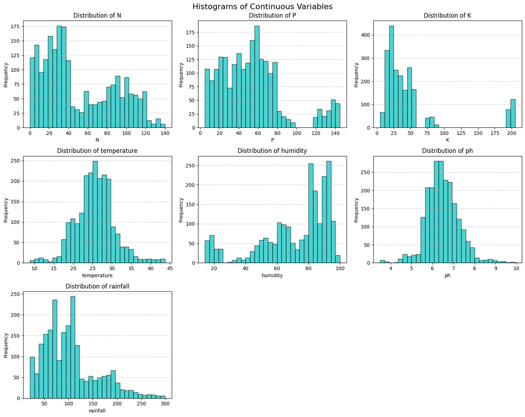

```python
continuous_vars = ['N', 'P', 'K', 'temperature', 'humidity', 'ph', 'rainfall']
fig, axes = plt.subplots(3, 3, figsize=(15, 12))
axes = axes.flatten()
for i, var in enumerate(continuous_vars):
    ax = axes[i]
    ax.hist(df[var], bins=30, color='c', edgecolor='k', alpha=0.7)
    ax.set_title(f'Distribution of {var}', fontsize=12)
    ax.set_xlabel(var, fontsize=10)
    ax.set_ylabel('Frequency', fontsize=10)
    ax.grid(axis='y', linestyle='--', alpha=0.7)


for i in range(len(continuous_vars), len(axes)):
    axes[i].set_visible(False)

fig.suptitle('Histograms of Continuous Variables', fontsize=16)

plt.tight_layout(rect=[0, 0, 1, 1])
plt.show()
```

- **Box Plots**: Create box plots of `temperature`, `humidity`, and `rainfall` grouped by `label` (recommended crop) to detect outliers.

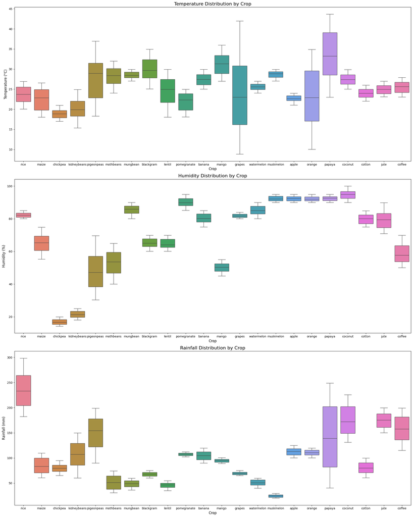

```python
fig, axes = plt.subplots(3, 1, figsize=(20, 25))

# boxplot for temperature
sns.boxplot(x='label', y='temperature',hue='label', data=df, ax=axes[0])
axes[0].set_title('Temperature Distribution by Crop', fontsize=16)
axes[0].set_xlabel('Crop', fontsize=12)
axes[0].set_ylabel('Temperature (°C)', fontsize=12)
axes[0].tick_params(axis='x')

# boxplot for humidity
sns.boxplot(x='label', y='humidity', hue='label',data=df, ax=axes[1])
axes[1].set_title('Humidity Distribution by Crop', fontsize=16)
axes[1].set_xlabel('Crop', fontsize=12)
axes[1].set_ylabel('Humidity (%)', fontsize=12)
axes[1].tick_params(axis='x')

# boxplot for rainfall
sns.boxplot(x='label', y='rainfall', hue='label', data=df, ax=axes[2])
axes[2].set_title('Rainfall Distribution by Crop', fontsize=16)
axes[2].set_xlabel('Crop', fontsize=12)
axes[2].set_ylabel('Rainfall (mm)', fontsize=12)
axes[2].tick_params(axis='x')
plt.tight_layout()
plt.show()
```

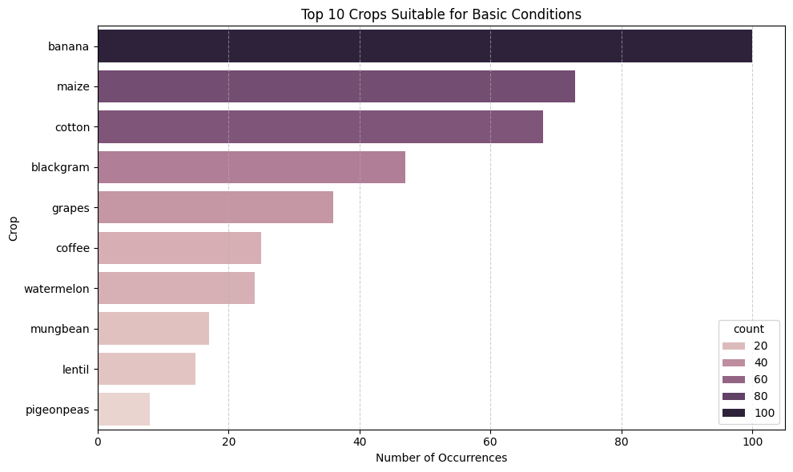

```python
basic_condition_df = df[
    (df['temperature'] >= 20) & (df['temperature'] <= 32) &
    (df['humidity'] >= 55) & (df['humidity'] <= 85) &
    (df['rainfall'] >= 50) & (df['rainfall'] <= 150) &
    (df['ph'] >= 5.3) & (df['ph'] <= 7.3)
]

# Count crop frequencies under basic conditions
popular_crops = basic_condition_df['label'].value_counts().head(10)

# Plot
plt.figure(figsize=(10, 6))
sns.barplot(x=popular_crops.values, y=popular_crops.index, hue=popular_crops)
plt.title("Top 10 Crops Suitable for Basic Conditions")
plt.xlabel("Number of Occurrences")
plt.ylabel("Crop")
plt.grid(axis='x', linestyle='--', alpha=0.6)
plt.tight_layout()
plt.show()
```

- **Correlation Heatmap**: Examine relationships between numerical input variables.

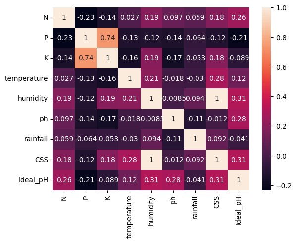

```python
plt.Figure(figsize=(25,20))
tc = df.corr(numeric_only=True)
sns.heatmap(tc,annot=True)
```

- **Pair Plot**: Scatterplot matrix of all features color-coded by crop label.

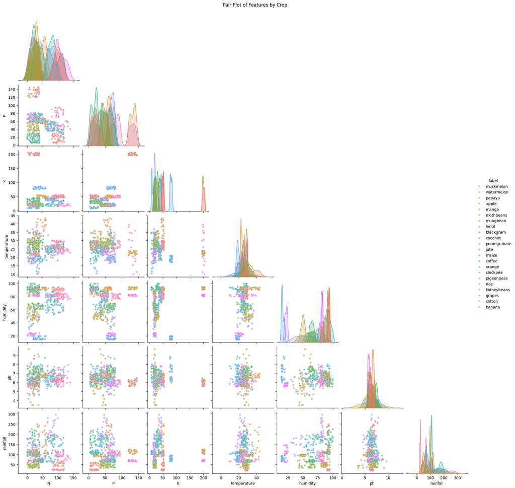

```python
# Select numeric features + label for plotting
features = ['N', 'P', 'K', 'temperature', 'humidity', 'ph', 'rainfall', 'label']

# To avoid overplotting (since you have 2200 rows), you can sample (optional)
df_sampled = df[features].sample(n=500, random_state=42)

# Create the pair plot
sns.pairplot(df_sampled, hue='label', corner=True, diag_kind='kde', plot_kws={'alpha': 0.6, 's': 25})
plt.suptitle("Pair Plot of Features by Crop", y=1.02)
plt.show()
```

- **Rainfall vs Humidity**: Scatter plot of `rainfall` vs `humidity` for each crop category, with trendlines.

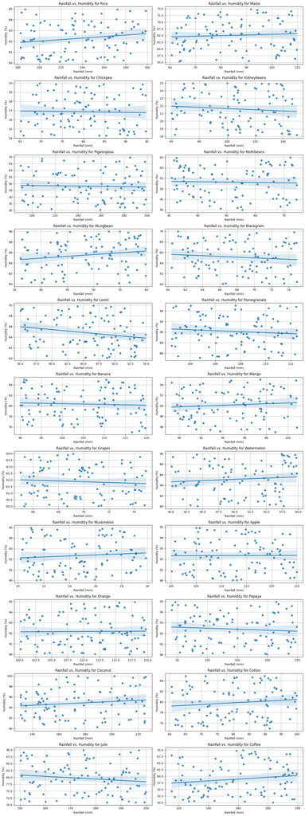

```python
crop_labels = df['label'].unique()

# Create a figure and a set of subplots in an 11x2 grid
fig, axes = plt.subplots(11, 2, figsize=(15, 40))

# Flatten the axes array to easily iterate over it
axes = axes.flatten()

# Loop through each crop label to create a scatter plot on a subplot
for i, crop in enumerate(crop_labels):
    # Filter the DataFrame for the specific crop
    crop_df = df[df['label'] == crop]

    # Create a scatter plot with a regression line on the appropriate subplot
    sns.regplot(data=crop_df, x='rainfall', y='humidity', ax=axes[i])

    # Set the title and labels for each subplot
    axes[i].set_title(f'Rainfall vs. Humidity for {crop.capitalize()}')
    axes[i].set_xlabel('Rainfall (mm)')
    axes[i].set_ylabel('Humidity (%)')
    axes[i].grid(True)

# Adjust the layout to prevent overlapping titles and labels
plt.tight_layout()
```

- **Stacked Bar Chart**: Show how nutrient requirements (`N`, `P`, `K`) differ across high-frequency crops.

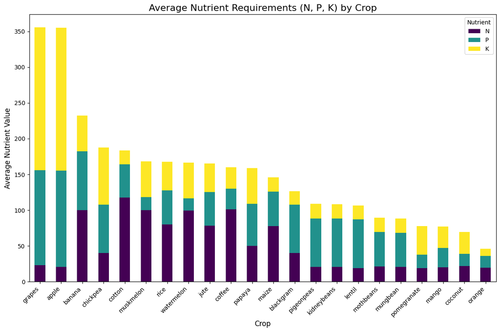

```python
nutrient_df = df.groupby('label')[['N', 'P', 'K']].mean()

# To make the chart more informative, let's sort the crops
# by their total nutrient requirement
nutrient_df['Total_Nutrients'] = nutrient_df['N'] + nutrient_df['P'] + nutrient_df['K']
nutrient_df = nutrient_df.sort_values(by='Total_Nutrients', ascending=False)
nutrient_df = nutrient_df.drop(columns=['Total_Nutrients'])

# Create a stacked bar chart
ax = nutrient_df.plot(kind='bar', stacked=True, figsize=(12, 8), colormap='viridis')

# Set the chart title and labels
plt.title('Average Nutrient Requirements (N, P, K) by Crop', fontsize=16)
plt.xlabel('Crop', fontsize=12)
plt.ylabel('Average Nutrient Value', fontsize=12)
plt.xticks(rotation=45, ha='right')
plt.legend(title='Nutrient')

# Adjust layout to make sure everything fits without overlapping
plt.tight_layout()
```

- **Mean pH Comparison**: Compare mean `ph` values across crop categories using a line plot or grouped bar chart.

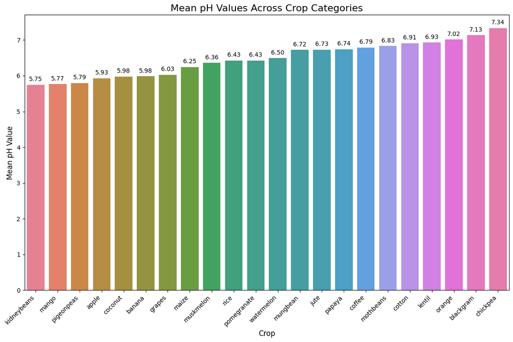

```python
mean_ph_df = df.groupby('label')['ph'].mean().sort_values().reset_index()

# Create the bar chart
plt.figure(figsize=(12, 8))
ax = sns.barplot(x='label', y='ph', data=mean_ph_df, hue='label')

# Set the chart title and labels
plt.title('Mean pH Values Across Crop Categories', fontsize=16)
plt.xlabel('Crop', fontsize=12)
plt.ylabel('Mean pH Value', fontsize=12)
plt.xticks(rotation=45, ha='right')

# Add the mean pH value on top of each bar for clarity
for p in ax.patches:
    ax.annotate(f'{p.get_height():.2f}',
                (p.get_x() + p.get_width() / 2., p.get_height()),
                ha='center', va='center',
                xytext=(0, 9),
                textcoords='offset points')

# Adjust layout to make sure everything fits without overlapping
plt.tight_layout()
```

- **pH Distribution**: Distribution plot of `ph` values. Count values in:
  - Acidic (pH < 6.5)
  - Neutral (6.5–7.5)
  - Basic (> 7.5)

```
Number of values in each pH range:
ph_category
Acidic     1203
Neutral     812
Basic       185
Name: count, dtype: int64
```

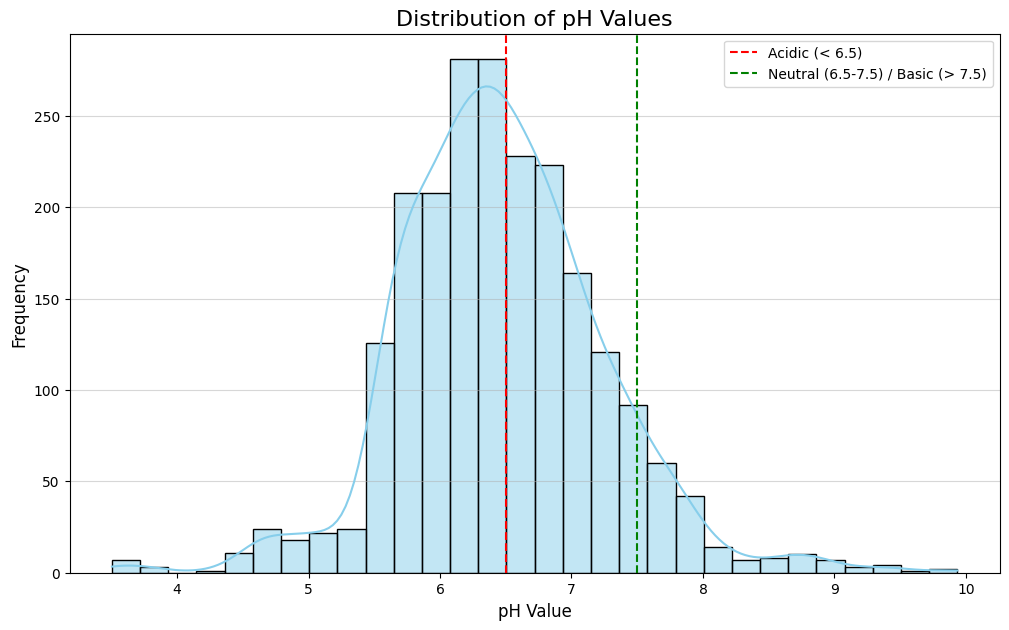

```python
def get_ph_category(ph):
    if ph < 6.5:
        return 'Acidic'
    elif 6.5 <= ph <= 7.5:
        return 'Neutral'
    else:
        return 'Basic'

# Apply the function to create a new 'ph_category' column
df['ph_category'] = df['ph'].apply(get_ph_category)

# Count the number of values in each category
ph_counts = df['ph_category'].value_counts()

# --- Plotting ---
plt.figure(figsize=(12, 7))

# Create the distribution plot (histogram)
sns.histplot(df['ph'], kde=True, bins=30, color='skyblue')

# Add vertical lines to show the category boundaries
plt.axvline(x=6.5, color='r', linestyle='--', label='Acidic (< 6.5)')
plt.axvline(x=7.5, color='g', linestyle='--', label='Neutral (6.5-7.5) / Basic (> 7.5)')

# Set titles and labels
plt.title('Distribution of pH Values', fontsize=16)
plt.xlabel('pH Value', fontsize=12)
plt.ylabel('Frequency', fontsize=12)
plt.legend()
plt.grid(axis='y', alpha=0.5)
print("Number of values in each pH range:")
print(ph_counts)
```

- **Z-Score Outliers**: Perform z-score-based outlier detection on `rainfall` and `ph`. Count and analyze the rows marked as outliers.

```python
# --- Z-score outlier detection ---
# Calculate the absolute Z-scores for 'rainfall' and 'ph'
df['rainfall_zscore'] = np.abs(stats.zscore(df['rainfall']))
df['ph_zscore'] = np.abs(stats.zscore(df['ph']))

# Identify outliers where the Z-score in either column is greater than 3
outliers = df[(df['rainfall_zscore'] > 3) | (df['ph_zscore'] > 3)]

# Count the total number of outliers
outlier_count = len(outliers)

# Display the total count and the first 5 outlier rows for analysis
print(f"Total number of outliers found: {outlier_count}")
print("\n--- Analysis of Outlier Rows (First 5) ---")
print(outliers[['label', 'rainfall', 'ph', 'rainfall_zscore', 'ph_zscore']].head())
```

```
Total number of outliers found: 52

--- Analysis of Outlier Rows (First 5) ---
   label    rainfall        ph  rainfall_zscore  ph_zscore
6   rice  271.324860  5.700806         3.055027   0.993425
12  rice  284.436457  5.108682         3.293655   1.758679
16  rice  276.655246  6.249051         3.152039   0.284880
19  rice  291.298662  5.853932         3.418545   0.795526
26  rice  271.358614  6.286500         3.055641   0.236481
```

### 4. Statistical Analysis

- **Descriptive Stats**: Calculate mean, median, variance, and standard deviation for each numerical variable.

```python
numerical_cols = ['N', 'P', 'K', 'temperature', 'humidity', 'ph', 'rainfall']
df_numerical = df[numerical_cols]

# Calculate the descriptive statistics
desc_stats = df_numerical.agg(['mean', 'median', 'var', 'std']).T

# Rename the columns for clarity
desc_stats.columns = ['Mean', 'Median', 'Variance', 'Standard Deviation']

# Print the final statistics table
print("Descriptive Statistics for Numerical Variables:")
print(desc_stats)
```

```
Descriptive Statistics for Numerical Variables:
                   Mean     Median     Variance  Standard Deviation
N             50.551818  37.000000  1362.889537           36.917334
P             53.362727  51.000000  1088.068460           32.985883
K             48.149091  32.000000  2565.212869           50.647931
temperature   25.616244  25.598693    25.641550            5.063749
humidity      71.481779  80.473146   495.677307           22.263812
ph             6.469480   6.425045     0.598980            0.773938
rainfall     103.463655  94.867624  3020.424469           54.958389
```

- **Crop Nutrient Summary**: Create summary tables showing average `N`, `P`, and `K` per crop.

```python
nutrient_summary = df.groupby('label')[['N', 'P', 'K']].mean()

# Display the summary table
print(nutrient_summary)
```

```
                  N       P       K
label
apple         20.80  134.22  199.89
banana       100.23   82.01   50.05
blackgram     40.02   67.47   19.24
chickpea      40.09   67.79   79.92
coconut       21.98   16.93   30.59
coffee       101.20   28.74   29.94
cotton       117.77   46.24   19.56
grapes        23.18  132.53  200.11
jute          78.40   46.86   39.99
kidneybeans   20.75   67.54   20.05
lentil        18.77   68.36   19.41
maize         77.76   48.44   19.79
mango         20.07   27.18   29.92
mothbeans     21.44   48.01   20.23
mungbean      20.99   47.28   19.87
muskmelon    100.32   17.72   50.08
orange        19.58   16.55   10.01
papaya        49.88   59.05   50.04
pigeonpeas    20.73   67.73   20.29
pomegranate   18.87   18.75   40.21
rice          79.89   47.58   39.87
watermelon    99.42   17.00   50.22
```

- **Coefficient of Variation**: Calculate for each feature — identify variable with highest relative variability.

```python
numerical_cols = ['N', 'P', 'K', 'temperature', 'humidity', 'ph', 'rainfall']
df_numerical = df[numerical_cols]

# Calculate the mean and standard deviation
stats_df = df_numerical.agg(['mean', 'std'])

# Calculate the Coefficient of Variation (CV)
# CV = (Standard Deviation / Mean) * 100
cv_df = (stats_df.loc['std'] / stats_df.loc['mean']) * 100
cv_df = cv_df.sort_values(ascending=False)

# Convert to a DataFrame for better presentation
cv_df = cv_df.reset_index()
cv_df.columns = ['Variable', 'Coefficient of Variation (%)']

# Print the results
print("Coefficient of Variation for Each Numerical Variable:")
print(cv_df)

# Identify and print the variable with the highest CV
highest_variability_variable = cv_df.iloc[0]
print(f"\nVariable with the highest relative variability: {highest_variability_variable['Variable']} ({highest_variability_variable['Coefficient of Variation (%)']:.2f}%)")
```

```
Coefficient of Variation for Each Numerical Variable:
      Variable  Coefficient of Variation (%)
0            K                    105.189796
1            N                     73.028696
2            P                     61.814462
3     rainfall                     53.118545
4     humidity                     31.146135
5  temperature                     19.767725
6           ph                     11.962904

Variable with the highest relative variability: K (105.19%)
```

- **Stability Analysis**: Determine top 3 crops with least variable environmental requirements.

```python
def calculate_cv(x):
    return (x.std() / x.mean()) * 100

# Group by crop and calculate the CV for each environmental variable
environmental_cols = ['temperature', 'humidity', 'ph', 'rainfall']
stability_df = df.groupby('label')[environmental_cols].agg(calculate_cv)

# Calculate the average CV across the environmental factors for each crop
stability_df['average_cv'] = stability_df.mean(axis=1)

# Sort the crops by their average CV to find the most stable
stable_crops = stability_df.sort_values(by='average_cv').head(3)

# Print the final results
print("Top 3 Crops with the Most Stable Environmental Requirements:")
print(stable_crops)
```

```
Top 3 Crops with the Most Stable Environmental Requirements:
           temperature  humidity        ph   rainfall  average_cv
label
apple         3.656072  1.579657  4.535360   6.305090    4.019045
muskmelon     3.004896  1.629923  3.640983  11.235337    4.877785
banana        5.217407  3.491222  4.522972   8.982530    5.553533
```

- **Crop Rankings**: Create ranking tables for all crops based on:
  1. Average nitrogen requirement
  2. Average rainfall
  3. Range of acceptable pH

```python
# --- 1. Nitrogen Ranking ---
# Ranks crops from highest to lowest nitrogen need
n_ranking = df.groupby('label')['N'].mean().sort_values(ascending=False).reset_index()
n_ranking['Rank'] = n_ranking.index + 1
n_ranking = n_ranking[['Rank', 'label', 'N']]
n_ranking.columns = ['Nitrogen Rank', 'Crop', 'Average Nitrogen']
print("--- Nitrogen Requirement Ranking ---")
print(n_ranking.to_string(index=False))
```

```
--- Nitrogen Requirement Ranking ---
 Nitrogen Rank        Crop  Average Nitrogen
             1      cotton            117.77
             2      coffee            101.20
             3   muskmelon            100.32
             4      banana            100.23
             5  watermelon             99.42
             6        rice             79.89
             7        jute             78.40
             8       maize             77.76
             9      papaya             49.88
            10    chickpea             40.09
            11   blackgram             40.02
            12      grapes             23.18
            13     coconut             21.98
            14   mothbeans             21.44
            15    mungbean             20.99
            16       apple             20.80
            17 kidneybeans             20.75
            18  pigeonpeas             20.73
            19       mango             20.07
            20      orange             19.58
            21 pomegranate             18.87
            22      lentil             18.77
```

```python
# --- 2. Rainfall Ranking ---
# Ranks crops from highest to lowest rainfall need
rainfall_ranking = df.groupby('label')['rainfall'].mean().sort_values(ascending=False).reset_index()
rainfall_ranking['Rank'] = rainfall_ranking.index + 1
rainfall_ranking = rainfall_ranking[['Rank', 'label', 'rainfall']]
rainfall_ranking.columns = ['Rainfall Rank', 'Crop', 'Average Rainfall']
print("\n--- Rainfall Requirement Ranking ---")
print(rainfall_ranking.to_string(index=False))
```

```
--- Rainfall Requirement Ranking ---
 Rainfall Rank        Crop  Average Rainfall
             1        rice        236.181114
             2     coconut        175.686646
             3        jute        174.792798
             4      coffee        158.066295
             5  pigeonpeas        149.457564
             6      papaya        142.627839
             7       apple        112.654779
             8      orange        110.474969
             9 pomegranate        107.528442
            10 kidneybeans        105.919778
            11      banana        104.626980
            12       mango         94.704515
            13       maize         84.766988
            14      cotton         80.398043
            15    chickpea         80.058977
            16      grapes         69.611829
            17   blackgram         67.884151
            18   mothbeans         51.198487
            19  watermelon         50.786219
            20    mungbean         48.403601
            21      lentil         45.680454
            22   muskmelon         24.689952
```

```python
# --- 3. Corrected pH Neutrality Ranking ---
# Ranks crops by how close their average pH is to a neutral 7.0
ph_neutrality = df.groupby('label')['ph'].mean().reset_index()
ph_neutrality['Difference_from_7'] = (ph_neutrality['ph'] - 7).abs()
ph_neutrality = ph_neutrality.sort_values(by='Difference_from_7')
ph_neutrality['Rank'] = range(1, len(ph_neutrality) + 1)
ph_neutrality = ph_neutrality[['Rank', 'label', 'ph']]
ph_neutrality.columns = ['Neutrality Rank', 'Crop', 'Average pH']
print("\n--- pH Neutrality Ranking (Closest to 7.0) ---")
print(ph_neutrality.to_string(index=False))
```

```
--- pH Neutrality Ranking (Closest to 7.0) ---
 Neutrality Rank        Crop  Average pH
               1      orange    7.016957
               2      lentil    6.927932
               3      cotton    6.912675
               4   blackgram    7.133952
               5   mothbeans    6.831174
               6      coffee    6.790308
               7      papaya    6.741442
               8        jute    6.732778
               9    mungbean    6.723957
              10    chickpea    7.336957
              11  watermelon    6.495778
              12 pomegranate    6.429172
              13        rice    6.425471
              14   muskmelon    6.358805
              15       maize    6.245190
              16      grapes    6.025937
              17      banana    5.983893
              18     coconut    5.976562
              19       apple    5.929663
              20  pigeonpeas    5.794175
              21       mango    5.766373
              22 kidneybeans    5.749411
```

- **Nutrient Percentiles**: 25th, 50th, 75th percentiles for each nutrient. Identify crops that thrive in extreme conditions.

```python
# --- 1. Calculate Percentile Distribution ---
# Define the nutrient columns
nutrient_cols = ['N', 'P', 'K']
# Calculate the 25th, 50th, and 75th percentiles for the nutrients
percentiles = df[nutrient_cols].quantile([0.25, 0.50, 0.75])
percentiles.index = ['25th Percentile', '50th Percentile (Median)', '75th Percentile']

print("--- Nutrient Percentile Distribution ---")
print(percentiles)
```

```
--- Nutrient Percentile Distribution ---
                              N     P     K
25th Percentile           21.00  28.0  20.0
50th Percentile (Median)  37.00  51.0  32.0
75th Percentile           84.25  68.0  49.0
```

```python
# --- 2. Identify Crops in Extreme Conditions ---
# Calculate the average nutrient requirement for each crop
avg_crop_needs = df.groupby('label')[nutrient_cols].mean()

# Get the 25th and 75th percentile values to use as thresholds
p25_thresholds = percentiles.loc['25th Percentile']
p75_thresholds = percentiles.loc['75th Percentile']

# Identify crops with high nutrient needs (> 75th percentile)
high_n_crops = avg_crop_needs[avg_crop_needs['N'] > p75_thresholds['N']].index.tolist()
high_p_crops = avg_crop_needs[avg_crop_needs['P'] > p75_thresholds['P']].index.tolist()
high_k_crops = avg_crop_needs[avg_crop_needs['K'] > p75_thresholds['K']].index.tolist()

# Identify crops with low nutrient needs (< 25th percentile)
low_n_crops = avg_crop_needs[avg_crop_needs['N'] < p25_thresholds['N']].index.tolist()
low_p_crops = avg_crop_needs[avg_crop_needs['P'] < p25_thresholds['P']].index.tolist()
low_k_crops = avg_crop_needs[avg_crop_needs['K'] < p25_thresholds['K']].index.tolist()
```

```python
# --- 3. Present the Analysis ---
print("\n--- Analysis of Crops in Extreme Conditions ---")

print("\n**Crops with High Nutrient Demand (> 75th Percentile):**")
print(f"High Nitrogen (needs > {p75_thresholds['N']:.2f}): {high_n_crops}")
print(f"High Phosphorus (needs > {p75_thresholds['P']:.2f}): {high_p_crops}")
print(f"High Potassium (needs > {p75_thresholds['K']:.2f}): {high_k_crops}")

print("\n**Crops Tolerant of Low Nutrients (< 25th Percentile):**")
print(f"Low Nitrogen (needs < {p25_thresholds['N']:.2f}): {low_n_crops}")
print(f"Low Phosphorus (needs < {p25_thresholds['P']:.2f}): {low_p_crops}")
print(f"Low Potassium (needs < {p25_thresholds['K']:.2f}): {low_k_crops}")
```

```
--- Analysis of Crops in Extreme Conditions ---

**Crops with High Nutrient Demand (> 75th Percentile):**
High Nitrogen (needs > 84.25): ['banana', 'coffee', 'cotton', 'muskmelon', 'watermelon']
High Phosphorus (needs > 68.00): ['apple', 'banana', 'grapes', 'lentil']
High Potassium (needs > 49.00): ['apple', 'banana', 'chickpea', 'grapes', 'muskmelon', 'papaya', 'watermelon']

**Crops Tolerant of Low Nutrients (< 25th Percentile):**
Low Nitrogen (needs < 21.00): ['apple', 'kidneybeans', 'lentil', 'mango', 'mungbean', 'orange', 'pigeonpeas', 'pomegranate']
Low Phosphorus (needs < 28.00): ['coconut', 'mango', 'muskmelon', 'orange', 'pomegranate', 'watermelon']
Low Potassium (needs < 20.00): ['blackgram', 'cotton', 'lentil', 'maize', 'mungbean', 'orange']
```

- **Skewness & Kurtosis**: Calculate for `rainfall`, `temperature`, and `ph` — interpret their distribution shape.

```python
# Select the columns for analysis
cols_of_interest = ['rainfall', 'temperature', 'ph']
data_subset = df[cols_of_interest]

# Calculate skewness and kurtosis
skewness_vals = data_subset.skew()
kurtosis_vals = data_subset.kurtosis()

# Combine into a single DataFrame for display
stats_summary = pd.DataFrame({
    'Skewness': skewness_vals,
    'Kurtosis': kurtosis_vals
})

# Print the results table
print("--- Skewness and Kurtosis of Environmental Variables ---")
print(stats_summary)
```

```
--- Skewness and Kurtosis of Environmental Variables ---
             Skewness  Kurtosis
rainfall     0.965756  0.607079
temperature  0.184933  1.232555
ph           0.283929  1.655581
```

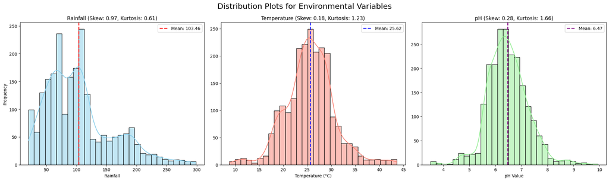

```python
# --- Calculate stats for titles ---
rainfall_skew = df['rainfall'].skew()
rainfall_kurt = df['rainfall'].kurtosis()
temp_skew = df['temperature'].skew()
temp_kurt = df['temperature'].kurtosis()
ph_skew = df['ph'].skew()
ph_kurt = df['ph'].kurtosis()

# --- Create the plots ---
# Set up a figure with 3 subplots arranged in a single row
fig, axes = plt.subplots(1, 3, figsize=(20, 6))
fig.suptitle('Distribution Plots for Environmental Variables', fontsize=18)

# Plot for Rainfall
sns.histplot(df['rainfall'], kde=True, ax=axes[0], color='skyblue', bins=30)
axes[0].axvline(df['rainfall'].mean(), color='red', linestyle='--', linewidth=2, label=f"Mean: {df['rainfall'].mean():.2f}")
axes[0].set_title(f"Rainfall (Skew: {rainfall_skew:.2f}, Kurtosis: {rainfall_kurt:.2f})")
axes[0].set_xlabel("Rainfall")
axes[0].set_ylabel("Frequency")
axes[0].legend()

# Plot for Temperature
sns.histplot(df['temperature'], kde=True, ax=axes[1], color='salmon', bins=30)
axes[1].axvline(df['temperature'].mean(), color='blue', linestyle='--', linewidth=2, label=f"Mean: {df['temperature'].mean():.2f}")
axes[1].set_title(f"Temperature (Skew: {temp_skew:.2f}, Kurtosis: {temp_kurt:.2f})")
axes[1].set_xlabel("Temperature (°C)")
axes[1].set_ylabel("") # Hide y-axis label for clarity
axes[1].legend()

# Plot for pH
sns.histplot(df['ph'], kde=True, ax=axes[2], color='lightgreen', bins=30)
axes[2].axvline(df['ph'].mean(), color='purple', linestyle='--', linewidth=2, label=f"Mean: {df['ph'].mean():.2f}")
axes[2].set_title(f"pH (Skew: {ph_skew:.2f}, Kurtosis: {ph_kurt:.2f})")
axes[2].set_xlabel("pH Value")
axes[2].set_ylabel("") # Hide y-axis label for clarity
axes[2].legend()

# Adjust layout to prevent titles/labels from overlapping
plt.tight_layout(rect=[0, 0, 1, 1]) # Adjust rect to make space for suptitle
```

## 5. Machine Leaning

### Step 1: Train/Test Split

Split the dataset into training and testing subsets using `train_test_split`.

```python
df.columns
```

```
Index(['N', 'P', 'K', 'temperature', 'humidity', 'ph', 'rainfall', 'label',
       'Nutrient_Ratio', 'CSS', 'Ideal_pH', 'ph_category', 'rainfall_zscore',
       'ph_zscore'],
      dtype='object')
```

```python
features = ['N','P','K','temperature','humidity','ph','rainfall','label']
d=  df[features]
X = d.drop('label',axis=1)
y = df['label']

# Split the dataset into training (80%) and testing (20%)
x_train, x_test, y_train, y_test = train_test_split(X, y, test_size = 0.20, random_state=42)

model_scores = []
```

### Decission Tree Classification -- Model 1

- Train the Decision Tree
- We initialize and train an `DecisionTreeClassifier` on the training data.

```python
model1 = DecisionTreeClassifier()
model1.fit(x_train,y_train)
y_pred = model1.predict(x_test)

accuracy1 = accuracy_score(y_pred,y_test)
accuracy1
print(f"Accuracy score for Decission tree is :{accuracy1}")


model_scores.append({'Model': 'Decision Tree', 'Accuracy': accuracy1})
```

```
Accuracy score for Decission tree is :0.9840909090909091
```

### Random Forest Classifiaction -- Model 2

- Train the Random Forest Classifier
- We initialize and train an `RandomForestClassifier` on the training data.

```python
model2 = RandomForestClassifier(n_estimators=100)
model2.fit(x_train,y_train)
y_pred = model2.predict(x_test)

accuracy2 = accuracy_score(y_pred,y_test)
accuracy2
print(f"Accuracy score for Decission tree is :{accuracy2}")
model_scores.append({'Model': 'Random Forset', 'Accuracy': accuracy2})
```

[output not shown]

### SVM -- Model 3

- Train the Support Vector Machines
- We initialize and train an `SVC` on the training data.

```python
model3 = SVC(kernel='rbf', C=1.0, random_state=42)
model3.fit(x_train, y_train)
y_pred = model3.predict(x_test)
accuracy3 = accuracy_score(y_test, y_pred)
print(f"Accuracy score for Decission tree is :{accuracy3}")
model_scores.append({'Model': 'SVM', 'Accuracy': accuracy3})
```

[output not shown]

### XG BOOST -- Model4

- Train the XGBoost Classifier
- We initialize and train an `XGBClassifier` on the training data.

```python
# label encoding crop label for xgb classifier using LabelEncoder
le = LabelEncoder()
y_train_encoded = le.fit_transform(y_train)
y_test_encoded = le.transform(y_test)
# Initialize and train the XGBoost classifier
model4 = XGBClassifier( eval_metric='logloss')
model4.fit(x_train, y_train_encoded)
y_pred = model4.predict(x_test)

accuracy4 = accuracy_score(y_pred,y_test_encoded)
accuracy4
print(f"Accuracy score for XG Boost is :{accuracy4}")
model_scores.append({'Model': 'XG Boost', 'Accuracy': accuracy4})
```

```
Accuracy score for XG Boost is :0.9863636363636363
```

### Model Accuracy Summary

```python
scores = pd.DataFrame(model_scores)
scores.index =scores.index+1
scores
```

|  | Model | Accuracy |
| --- | --- | --- |
| 1 | Decision Tree | 0.984091 |
| 2 | Random Forset | 0.993182 |
| 3 | SVM | 0.961364 |
| 4 | XG Boost | 0.986364 |

### Predicting Crop by Taking Input from the User

> Inputs required from the user:
- Nitrogen (N)
- Phosphorus (P)
- Potassium (K)
- Temperature (°C)
- Humidity (%)
- pH level
- Rainfall (mm)

The model will return the **most suitable crop** to grow under the given conditions.

```python
n = float(input("Enter the amount of Nitrogen in the soil: "))
p = float(input("Enter the amount of Phosphorus in the soil: "))
k = float(input("Enter the amount of Potassium in the soil: "))
temp = float(input("Enter the Temperature in Celsius (°C): "))
humidity = float(input("Enter the relative Humidity in percent (%): "))
ph = float(input("Enter the pH value of the soil: "))
rainfall = float(input("Enter the Rainfall in mm: "))


user_input = pd.DataFrame({
    'N': [n],
    'P': [p],
    'K': [k],
    'temperature': [temp],
    'humidity': [humidity],
    'ph': [ph],
    'rainfall': [rainfall]
})
## You can change model from here

prediction = model2.predict(user_input)


print(f"The most suitable crop for these conditions is: {prediction[0]}")
user_input
```

[output not shown]

### Running Model on Different Test Cases for Validation

> Each test case includes:
- Nitrogen (N)
- Phosphorus (P)
- Potassium (K)
- Temperature (°C)
- Humidity (%)
- pH level
- Rainfall (mm)

The model will predict the most suitable crop for each scenario, helping us validate its accuracy and consistency.

```python
test_cases_data = {
    'Case 1 (Ideal for Rice)': [90, 42, 43, 23.5, 82, 6.5, 202],
    'Case 2 (Ideal for Apple)': [23, 130, 200, 23.5, 91.5, 6.3, 114],
    'Case 3 (Ideal for Grapes)': [23, 132, 200, 24, 81, 6.7, 70],
    'Case 4 (Good for Chickpea)': [40, 68, 79, 19, 17, 7.5, 75],
    'Case 5 (Good for Coconut)': [22, 18, 30, 27.5, 95, 6.0, 175],
    'Case 6 (Unusual Mix 1)': [120, 80, 50, 28, 70, 7, 150],
    'Case 7 (Unusual Mix 2)': [50, 50, 50, 15, 85, 5.5, 45]
}
test_cases_df = pd.DataFrame.from_dict(
    test_cases_data,
    orient='index',
    columns=['N', 'P', 'K', 'temperature', 'humidity', 'ph', 'rainfall']
)
prediction = model2.predict(test_cases_df)
predictions = model2.predict(test_cases_df)
test_cases_df['Predicted Crop'] = predictions
print("Running the model on multiple test cases...")
test_cases_df
```

```
Running the model on multiple test cases...
```

|  | N | P | K | temperature | humidity | ph | rainfall | Predicted Crop |
| --- | --- | --- | --- | --- | --- | --- | --- | --- |
| Case 1 (Ideal for Rice) | 90 | 42 | 43 | 23.5 | 82.0 | 6.5 | 202 | rice |
| Case 2 (Ideal for Apple) | 23 | 130 | 200 | 23.5 | 91.5 | 6.3 | 114 | apple |
| Case 3 (Ideal for Grapes) | 23 | 132 | 200 | 24.0 | 81.0 | 6.7 | 70 | grapes |
| Case 4 (Good for Chickpea) | 40 | 68 | 79 | 19.0 | 17.0 | 7.5 | 75 | chickpea |
| Case 5 (Good for Coconut) | 22 | 18 | 30 | 27.5 | 95.0 | 6.0 | 175 | coconut |
| Case 6 (Unusual Mix 1) | 120 | 80 | 50 | 28.0 | 70.0 | 7.0 | 150 | banana |
| Case 7 (Unusual Mix 2) | 50 | 50 | 50 | 15.0 | 85.0 | 5.5 | 45 | papaya |

## 6. Tableau Dashboard

- Customise Dashboard
- Display all types of Crops
- Take input Values
- Bar Chart
- Heat Map
- Radar Chart
- Pie Chart

[figure not shown]